# Deconvolution of the tumor microenvironment with omnideconv

## 1. Introduction and dataset

In this vignette, we will use the omnideconv package to deconvolve a bulk RNA-seq dataset from 24 breast cancer patients with two different methods (DWLS and BayesPrism). The datasets are from a recent breast cancer study (Wu et al. 2021). This study provides access to a primary-tumor single cell RNA-seq (scRNA-seq) dataset from 26 breast cancer patients across three major cancer subtypes (ER+, HER2+, TNBC). The dataset includes cell-type annotation for three resolution levels. In addition, the data includes bulk RNA-seq sequencing for 24 of the patients. In this chapter, we use multi-sample, breast-cancer scRNA-seq atlas (100,064 cells) as a reference to train the methods for the deconvolution of the bulk RNA-seq samples. The single-cell and bulk RNA-seq data is deposited on GEO, under accession number: GSE176078. The single cell data comes with the author’s cell type annotations. We will need to download and unzip the datasets (`GSE176078_Wu_etal_2021_BRCA_scRNASeq.tar.gz`, `GSE176078_Wu_etal_2021_bulkRNAseq_raw_counts.txt.gz`), and store them in a data directory. For this example analysis, we will also need the additional clinical information about the patients, available as [Supplementary Table 1](https://static-content.springer.com/esm/art%3A10.1038%2Fs41588-021-00911-1/MediaObjects/41588_2021_911_MOESM4_ESM.xlsx) from the paper.

## 2. Library loading

```r
library(Seurat)
library(tidyverse)
library(omnideconv)
library(readxl)
```

## 3. Single cell data processing

Although not strictly required by omnideconv, we suggest performing quality control and filtering of the input scRNA-seq data according to the best practice (Heumos et al. 2023), to ensure the best training conditions for deconvolution algorithms. We first pre-process the single-cell dataset to remove low-quality cells. We will use the R package [Seurat](https://github.com/satijalab/seurat) (Hao et al. 2023), which allows fast and easy manipulation of single-cell data. We will create a Seurat object with the cell counts and their metadata of interest curated by the authors, which include cell-type annotation on three levels of resolution:

```r
single.cell.data <- Seurat::ReadMtx(
  mtx = "path/to/Wu_etal_2021_BRCA_scRNASeq/count_matrix_sparse.mtx",
  cells = "path/to/Wu_etal_2021_BRCA_scRNASeq/count_matrix_barcodes.tsv",
  features = "path/to/Wu_etal_2021_BRCA_scRNASeq/count_matrix_genes.tsv",
  feature.column = 1
)
single.cell.metadata <- read.table("path/to/Wu_etal_2021_BRCA_scRNASeq/metadata.csv",
                                   sep = ",", header = TRUE, row.names = 1)

single.cell.data <- CreateSeuratObject(single.cell.data,
                                       project = "Wu_dataset", assay = "RNA",
                                       min.cells = 0, min.features = 1,
                                       meta.data = single.cell.metadata)
```

We can have an overview of the number of cells per cell type in the dataset:

Number of cells per cell type

| celltype_major | number_cells |
| --- | --- |
| B-cells | 3206 |
| CAFs | 6573 |
| Cancer Epithelial | 24489 |
| Endothelial | 7605 |
| Myeloid | 9675 |
| Normal Epithelial | 4355 |
| Plasmablasts | 3524 |
| PVL | 5423 |
| T-cells | 35214 |

In order to do this filtering, we will create a function to identify the outliers for each metric:

```r
is_outlier <- function(SeuratObject, metric, nmads) {
  eval(parse(text = paste0("M <- SeuratObject$", metric)))
  outlier <- (M < median(M) - nmads * mad(M)) | (M > median(M) + nmads * mad(M))
  return(outlier)
}

check_outliers_nFeature <- is_outlier(single.cell.data, "nFeature_RNA", 5)
check_outliers_nCount <- is_outlier(single.cell.data, "nCount_RNA", 5)
check_outliers_mito <- is_outlier(single.cell.data, "percent.mito", 3)

non_outliers_nFeature <- names(check_outliers_nFeature[!check_outliers_nFeature])
non_outliers_nCount <- names(check_outliers_nCount[!check_outliers_nCount])
non_outliers_mito <- names(check_outliers_mito[!check_outliers_mito])

non_outliers <- intersect(non_outliers_nFeature, non_outliers_nCount) %>%
  intersect(non_outliers_mito)

single.cell.data <- subset(single.cell.data, cells = non_outliers)
```

Number of cells per cell type after quality filtering

| celltype_major | number_cells |
| --- | --- |
| B-cells | 3150 |
| CAFs | 6154 |
| Cancer Epithelial | 16613 |
| Endothelial | 6991 |
| Myeloid | 8855 |
| Normal Epithelial | 3533 |
| Plasmablasts | 3164 |
| PVL | 5120 |
| T-cells | 34991 |

## 4. Bulk data preprocessing

We will now read in the bulk sequencing data file, which consists of 24 samples.

```r
bulk.data <- read.table("path/to/GSE176078_Wu_etal_2021_bulkRNAseq_raw_counts.txt", skip = 1)
header <- read.table("path/to/GSE176078_Wu_etal_2021_bulkRNAseq_raw_counts.txt",
                     header = FALSE, nrows = 1, skipNul = TRUE, sep = "\t")
colnames(bulk.data) <- c("Genes", gsub("A|N", "", header[2:25]))
bulk.data <- bulk.data[bulk.data$Genes != "", ]
bulk.data <- column_to_rownames(bulk.data, "Genes")
bulk.data <- as.matrix(bulk.data)
```

## 5. Subsampling of single cell data

The various methods included in omnideconv rely on the single cell dataset that will be used to train them for the deconvolution of those specific cell types. This training involves the optimization of internal features of the methods and can happen in different ways. Some methods use the single cell data to build a ‘signature matrix’, i.e. a reduced transcriptional fingerprints of the cell types provided, while others use this data in a statistical or deep learning model. Since single cell datasets can often encompass thousands of cells, we will need to subsample it in order to be able to run the analysis on our machines. In this case we will retain a maximum of 200 cells per cell type, but this step can be customized, or eventually skipped, depending on the computational resources available.

```r
max_cells_per_celltype <- 200

sampled.metadata <- single.cell.data@meta.data %>%
  rownames_to_column("barcode") %>%
  group_by(celltype_major) %>%
  nest() %>%
  mutate(n = map_dbl(data, nrow)) %>%
  mutate(n = min(n, max_cells_per_celltype)) %>%
  ungroup() %>%
  mutate(samp = map2(data, n, sample_n)) %>%
  select(-data) %>%
  unnest(samp)

single.cell.data.sampled <- subset(single.cell.data, cells = sampled.metadata$barcode)
```

Number of cells per cell type after subsampling

| celltype_major | number_cells |
| --- | --- |
| B-cells | 200 |
| CAFs | 200 |
| Cancer Epithelial | 200 |
| Endothelial | 200 |
| Myeloid | 200 |
| Normal Epithelial | 200 |
| Plasmablasts | 200 |
| PVL | 200 |
| T-cells | 200 |

## 6. Deconvolution of the bulk data

Each method has different requirements, but in general to compute the deconvolution results we will need the single cell counts matrix, the cell type annotations and the information on the individual/experiment from which the cells were retrieved (batch ID).

```r
counts.matrix <- as.matrix(single.cell.data.sampled@assays$RNA@counts)
cell.type.annotations <- single.cell.data.sampled$celltype_major
batch.ids <- single.cell.data.sampled$orig.ident
```

### 6.1 Deconvolution with DWLS

Now we’re going to deconvolute the bulk dataset with different methods. The first one we are going to use is called DWLS (Tsoucas et al. 2019) and performs the deconvolution in a two-step process. First, the single cell data is used to build a signature matrix using the `omnideconv` function `build_model`. DWLS looks for differentially expressed genes that discriminate across cell types, and can do so with two approaches based either on the Seurat (Hao et al. 2023) “bimod” test (McDavid et al. 2012) or on MAST (Finak et al. 2015). MAST improves the former model, but has an increased computational requirement (Nault et al. 2022). The authors recommend using this method on the smaller datasets, and to switch to Seurat if the analysis with MAST cannot be completed. To reduce MAST’s computational time, we introduced a second version of the MAST-based function (mast_optimized) that speeds up the process compared to the original implementation:

```r
signature.matrix.dwls <- omnideconv::build_model(
  single_cell_object = counts.matrix,
  cell_type_annotations = cell.type.annotations,
  method = "dwls",
  dwls_method = "mast_optimized"
)
```

This signature is optimized so that the genes selected are the ones that help to discriminate across cell types.

The signature is now used for the deconvolution of the bulk RNAseq, which is performed with the `omnideconv` function `deconvolute`. DWLS computes the cell fractions performing one of Ordinary Least Squares (OLS) Regression, Support Vector Regression (SVR) or the Dampened Weighted Least Squares Regression (DWLS) that was introduced with the method. This last regression method is shown to outperform the others when it comes to the detection of rare cell types:

```r
deconvolution.results.dwls <- deconvolute(
  bulk_gene_expression = bulk.data,
  model = signature.matrix.dwls,
  method = "dwls",
  dwls_submethod = "DampenedWLS"
)
```

We will now obtain, for every sample, a set of cell type fractions for each cell type that was included in the provided single cell dataset.

Cell type fractions obtained by DWLS

[output not shown]

We can also visualise the results as a barplot through the built-in `plot_deconvolution` function:

```r
omnideconv::plot_deconvolution(list("dwls" = deconvolution.results.dwls), "bar", "method", "Spectral")
```

[output not shown]

### 6.2 Deconvolution with BayesPrism

```r
deconvolution.results.bayesprism <- deconvolute(
  bulk_gene_expression = bulk.data,
  single_cell_object = counts.matrix,
  cell_type_annotations = cell.type.annotations,
  model = NULL,
  method = "bayesprism",
  n_cores = 12
)
```

We can visualize the results as before:

```r
omnideconv::plot_deconvolution(list("bayesprism" = deconvolution.results.bayesprism), "bar", "method", "Spectral")
```

[output not shown]

## 7. Deconvolution of the bulk data at a lower resolution

The considered single-cell breast cancer dataset includes cell-type annotations at three levels of resolution: `celltype_major`, `celltype_minor`, and `celltype_subset`, which distinguish 9, 29, and 58 cell types respectively. The different cell-type annotations can be accessed with:

```r
single.cell.data$celltype_major   # Major annotation
single.cell.data$celltype_minor   # Minor annotation
single.cell.data$celltype_subset  # Subset annotation
```

These additional annotations provide a cell-type classification at a finer resolution. For instance, at the `celltype_major` level, we only have the T cell population, while at the `celltype_minor` level, we can distinguish between CD4+ and CD8+ T cells. In the following, we will again perform deconvolution analysis with DWLS but, this time, using the `celltype_minor` information. We will subsample the dataset as before, this time considering the second level of resolution for the cell types, and extract the objects needed for deconvolution.

```r
max_cells_per_celltype <- 200

sampled.metadata <- single.cell.data@meta.data %>%
  rownames_to_column("barcode") %>%
  group_by(celltype_minor) %>%
  nest() %>%
  mutate(n = map_dbl(data, nrow)) %>%
  mutate(n = min(n, max_cells_per_celltype)) %>%
  ungroup() %>%
  mutate(samp = map2(data, n, sample_n)) %>%
  select(-data) %>%
  unnest(samp)

single.cell.data.sampled <- subset(single.cell.data, cells = sampled.metadata$barcode)
```

Number of cells per cell type (minor resolution) after subsampling

| celltype_minor | number_cells |
| --- | --- |
| B cells Memory | 200 |
| B cells Naive | 200 |
| CAFs MSC iCAF-like | 200 |
| CAFs myCAF-like | 200 |
| Cancer Basal SC | 200 |
| Cancer Cycling | 200 |
| Cancer Her2 SC | 200 |
| Cancer LumA SC | 200 |
| Cancer LumB SC | 200 |
| Cycling PVL | 37 |
| Cycling T-cells | 200 |
| Cycling_Myeloid | 200 |
| DCs | 200 |
| Endothelial ACKR1 | 200 |
| Endothelial CXCL12 | 200 |
| Endothelial Lymphatic LYVE1 | 183 |
| Endothelial RGS5 | 200 |
| Luminal Progenitors | 200 |
| Macrophage | 200 |
| Mature Luminal | 200 |
| Monocyte | 200 |
| Myoepithelial | 200 |
| NK cells | 200 |
| NKT cells | 200 |
| Plasmablasts | 200 |
| PVL Differentiated | 200 |
| PVL Immature | 200 |
| T cells CD4+ | 200 |
| T cells CD8+ | 200 |

```r
counts.matrix <- as.matrix(single.cell.data.sampled@assays$RNA@counts)
cell.type.annotations <- single.cell.data.sampled$celltype_minor
batch.ids <- single.cell.data.sampled$orig.ident

signature.matrix.dwls.minor <- omnideconv::build_model(
  single_cell_object = counts.matrix,
  cell_type_annotations = cell.type.annotations,
  method = "dwls",
  dwls_method = "mast_optimized"
)

deconvolution.results.dwls.minor <- deconvolute(
  bulk_gene_expression = bulk.data,
  model = signature.matrix.dwls.minor,
  method = "dwls",
  dwls_submethod = "DampenedWLS"
)
```

We can visualize the results as before:

```r
omnideconv::plot_deconvolution(list("dwls" = deconvolution.results.dwls.minor), "bar", "method", "Spectral")
```

[output not shown]

## 8. Comparison of cell fractions across conditions

We can consider as well the metadata provided with the original paper, which include patient’s data, cancer subtype information and treatment details. We can first harmonize the sample names, and then combine all this information with the deconvolution results in one dataframe.

```r
patient.metadata <- read_excel("vignette_files/41588_2021_911_MOESM4_ESM.xlsx",
                               sheet = 1, skip = 3) %>%
  select(c(1, 4, 5, 11, 12))
colnames(patient.metadata) <- c("Sample", "Grade", "Cancer_type", "IHC_subtype", "Treatment")
patient.metadata$Sample <- gsub("-", "", patient.metadata$Sample) %>%
  paste0("CID", .)

patients.results <- rownames_to_column(as.data.frame(deconvolution.results.dwls), "Sample") %>%
  gather(key = "celltype", value = "cell_fraction", -Sample) %>%
  left_join(patient.metadata, by = "Sample")
```

Each condition has a different number of samples:

| IHC subtype | n |
| --- | --- |
| ER+ | 12 |
| HER2+ | 2 |
| HER2+/ER+ | 2 |
| TNBC | 8 |

We can visualize the estimated cell fractions across samples with a boxplot, and group the results by IHC subtype:

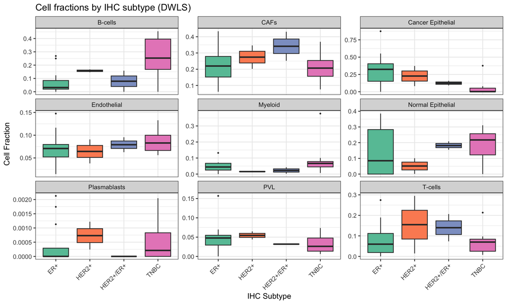

```r
patients.results %>%
  filter(!is.na(IHC_subtype)) %>%
  ggplot(aes(x = IHC_subtype, y = cell_fraction, fill = IHC_subtype)) +
  geom_boxplot(outlier.size = 0.5) +
  facet_wrap(~celltype, scales = "free_y", ncol = 3) +
  theme_bw() +
  theme(axis.text.x = element_text(angle = 45, hjust = 1),
        legend.position = "none") +
  scale_fill_brewer(palette = "Set2") +
  labs(x = "IHC Subtype", y = "Cell Fraction",
       title = "Cell fractions by IHC subtype (DWLS)")
```

HER2-positive samples are enriched in T cells, while the ER-positive and triple negative breast cancer (TNBC) samples show an enrichment in cancer and normal epithelial cells, respectively. The patient metadata includes information about eventual treatments undergone by the patients. We can see that 5 out of the 24 patients were treated with Neoadjuvant and/or Paclitaxel, while the other 19 were untreated. We can therefore visualize the distribution of cell fractions across treated and untreated patients:

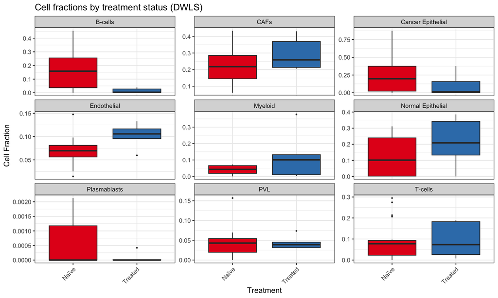

```r
patients.results %>%
  filter(!is.na(Treatment)) %>%
  ggplot(aes(x = Treatment, y = cell_fraction, fill = Treatment)) +
  geom_boxplot(outlier.size = 0.5) +
  facet_wrap(~celltype, scales = "free_y", ncol = 3) +
  theme_bw() +
  theme(axis.text.x = element_text(angle = 45, hjust = 1),
        legend.position = "none") +
  scale_fill_brewer(palette = "Set1") +
  labs(x = "Treatment", y = "Cell Fraction",
       title = "Cell fractions by treatment status (DWLS)")
```

The major differences in this case are the enrichment of the CAFs and normal epithelial cells in the treated samples, as opposed to the cancer epithelial cells and B cells which have a higher median cell fraction in the untreated samples.

As mentioned before, with the lower level of annotations we can identify additional cell types, such as CD4+/CD8+ subtypes, Fibroblasts and cancer cells. We can therefore visualize the estimated cell fractions in a boxplot, focusing in particular on the CD4+ and CD8+ T-cell subtypes:

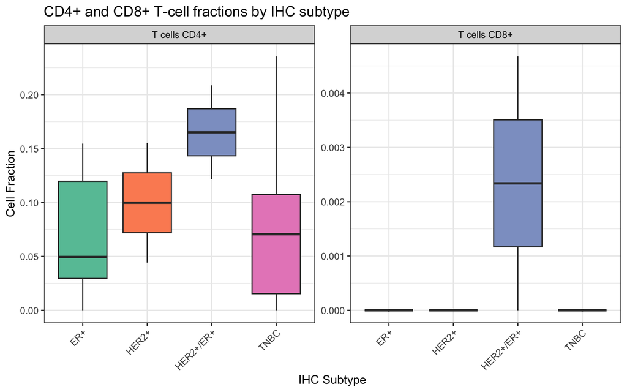

```r
patients.results.minor %>%
  filter(celltype %in% c("T cells CD4+", "T cells CD8+"), !is.na(IHC_subtype)) %>%
  ggplot(aes(x = IHC_subtype, y = cell_fraction, fill = IHC_subtype)) +
  geom_boxplot(outlier.size = 0.5) +
  facet_wrap(~celltype, scales = "free_y") +
  theme_bw() +
  theme(axis.text.x = element_text(angle = 45, hjust = 1),
        legend.position = "none") +
  scale_fill_brewer(palette = "Set2") +
  labs(x = "IHC Subtype", y = "Cell Fraction",
       title = "CD4+ and CD8+ T-cell fractions by IHC subtype")
```

Similarly, we can visualize the distribution of the estimates for the cancer associated fibroblasts (CAFs), respectively the myoblastic CAFs (myCAF) and the bone marrow derived inflammatory CAFs (MSC iCAF):

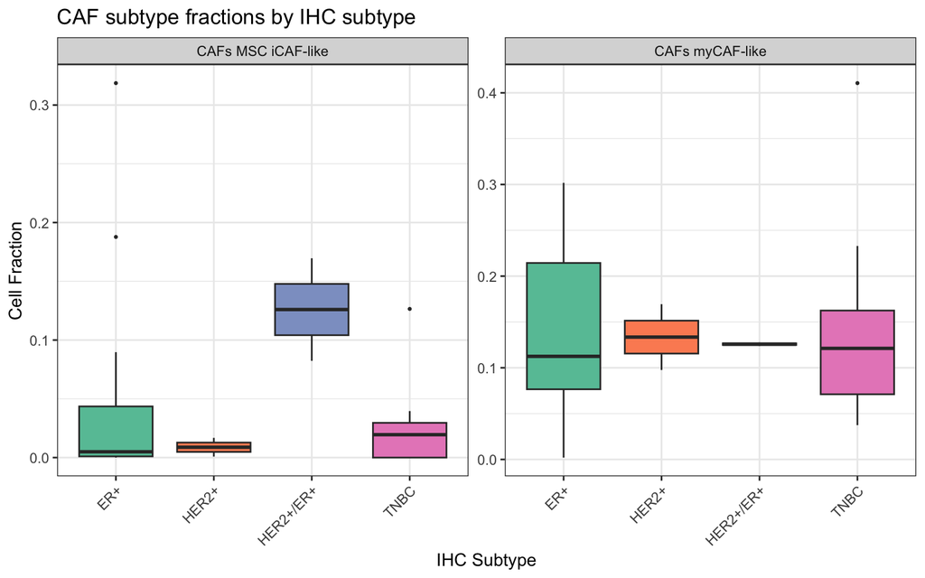

```r
patients.results.minor %>%
  filter(celltype %in% c("CAFs myCAF-like", "CAFs MSC iCAF-like"), !is.na(IHC_subtype)) %>%
  ggplot(aes(x = IHC_subtype, y = cell_fraction, fill = IHC_subtype)) +
  geom_boxplot(outlier.size = 0.5) +
  facet_wrap(~celltype, scales = "free_y") +
  theme_bw() +
  theme(axis.text.x = element_text(angle = 45, hjust = 1),
        legend.position = "none") +
  scale_fill_brewer(palette = "Set2") +
  labs(x = "IHC Subtype", y = "Cell Fraction",
       title = "CAF subtype fractions by IHC subtype")
```

Here we can notice that, while the myoblastic CAFs have a comparable median value, the MSC CAFs have higher infiltration in the samples characterized as HER2+/ER+ subtype.

Finally, we can visualize the distribution of the different cancer cells molecular subtypes that were described by the authors:

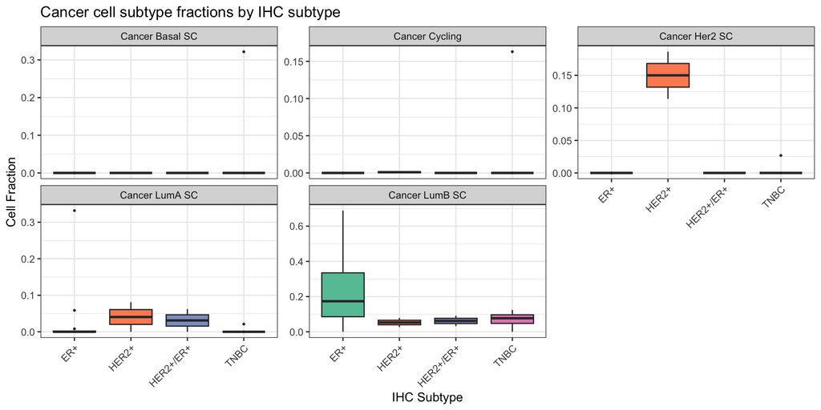

```r
patients.results.minor %>%
  filter(grepl("^Cancer", celltype), !is.na(IHC_subtype)) %>%
  ggplot(aes(x = IHC_subtype, y = cell_fraction, fill = IHC_subtype)) +
  geom_boxplot(outlier.size = 0.5) +
  facet_wrap(~celltype, scales = "free_y", ncol = 3) +
  theme_bw() +
  theme(axis.text.x = element_text(angle = 45, hjust = 1),
        legend.position = "none") +
  scale_fill_brewer(palette = "Set2") +
  labs(x = "IHC Subtype", y = "Cell Fraction",
       title = "Cancer cell subtype fractions by IHC subtype")
```

We can see that the HER2+ shows an overrepresentation of the cancer cells described as HER2-like by the authors. Similarly, the ER+ samples show higher fractions of Luminal B cancer cells. These findings on bulk RNA-seq are concordant with the subtypings that the authors described on the single cell RNA-seq (‘Results - scSubtype’).

## References

Chu, Tinyi, Zhong Wang, Dana Pe’er, and Charles G. Danko. 2022. “Cell Type and Gene Expression Deconvolution with BayesPrism Enables Bayesian Integrative Analysis Across Bulk and Single-Cell RNA Sequencing in Oncology.” *Nature Cancer* 3 (4): 505–17. https://doi.org/10.1038/s43018-022-00356-3.

Finak, Greg, Andrew McDavid, Masanao Yajima, Jingyuan Deng, Vivian Gersuk, Alex K. Shalek, Chloe K. Slichter, et al. 2015. “MAST: A Flexible Statistical Framework for Assessing Transcriptional Changes and Characterizing Heterogeneity in Single-Cell RNA Sequencing Data.” *Genome Biology* 16 (1). https://doi.org/10.1186/s13059-015-0844-5.

Hao, Yuhan, Tim Stuart, Madeline H. Kowalski, Saket Choudhary, Paul Hoffman, Austin Hartman, Avi Srivastava, et al. 2023. “Dictionary Learning for Integrative, Multimodal and Scalable Single-Cell Analysis.” *Nature Biotechnology* 42 (2): 293–304. https://doi.org/10.1038/s41587-023-01767-y.

Heumos, Lukas, Anna C. Schaar, Christopher Lance, Anastasia Litinetskaya, Felix Drost, Luke Zappia, Malte D. Lücken, et al. 2023. “Best Practices for Single-Cell Analysis Across Modalities.” *Nature Reviews Genetics* 24 (8): 550–72. https://doi.org/10.1038/s41576-023-00586-w.

McDavid, Andrew, Greg Finak, Pratip K. Chattopadyay, Maria Dominguez, Laurie Lamoreaux, Steven S. Ma, Mario Roederer, and Raphael Gottardo. 2012. “Data Exploration, Quality Control and Testing in Single-Cell qPCR-Based Gene Expression Experiments.” *Bioinformatics* 29 (4): 461–67. https://doi.org/10.1093/bioinformatics/bts714.

Nault, Rance, Satabdi Saha, Sudin Bhattacharya, Jack Dodson, Samiran Sinha, Tapabrata Maiti, and Tim Zacharewski. 2022. “Benchmarking of a Bayesian Single Cell RNAseq Differential Gene Expression Test for Dose–Response Study Designs.” *Nucleic Acids Research* 50 (8): e48–48. https://doi.org/10.1093/nar/gkac019.

Tsoucas, Daphne, Rui Dong, Haide Chen, Qian Zhu, Guoji Guo, and Guo-Cheng Yuan. 2019. “Accurate Estimation of Cell-Type Composition from Gene Expression Data.” *Nature Communications* 10 (1). https://doi.org/10.1038/s41467-019-10802-z.

Wu, Sunny Z., Ghamdan Al-Eryani, Daniel Lee Roden, Simon Junankar, Kate Harvey, Alma Andersson, Aatish Thennavan, et al. 2021. “A Single-Cell and Spatially Resolved Atlas of Human Breast Cancers.” *Nature Genetics* 53 (9): 1334–47. https://doi.org/10.1038/s41588-021-00911-1.